# Sample swap check

Darren Cameron

2025-09-10

## Sample swap check process

1. `copy_bam`: For each sublibrary and plate combination, copy BAM file from neurocluster to scratch:
   - BAM located here: `<src_dir>/plate3/1_plate3/process/barcode_headAligned_anno.bam`
2. `make_whitelist`: Generated cell whitelist files from cell metadata for each sublibrary and plate.
   - Whitelist located here: `<src_dir>/plate3/1_plate3/all-sample/DGE_filtered/cell_metadata.csv`
3. `subset_vcf`: Subset TOPMed dbSNP VCF to chr-specific files
   - SNP ref: TOPMed freeze 5, hg38, filtered for informative SNPs (MAF ≥ 0.1, depth ≥ 20) - to save running time / mem (same ref used for pre-imputation genotyping harmonisation)
4. `sort_bam`: Sorted BAM files by coordinates for each sublibrary.
5. `index_bam`: Indexed sorted BAM files
6. `extract_and_recode_chr`: Extracted chr-specific reads from sorted BAMs
   - Recoded headers to standardise chr names (e.g., hg38_chrX to chrX)
7. `cellsnp-lite` generate per-cell allele counts (pile-ups) at informative SNP positions
   - Quantifies SNP genotypes for each cell using chr-specific BAMs and filtered ref VCF
   - [PMID:33963851](https://academic.oup.com/bioinformatics/article/37/23/4569/6272512?login=false)
   - Cell / sample ids are tracked using Parse cell whitelist for each sublibrary, plate, chr combination
   - Need to vary the SNP filtering based on chr, running times etc. chr22 has too few SNPs
8. `vireo`: infer donor identities by matching cell SNP profiles to actual donor genotypes
   - Assigns cells to donors based on probabilistic SNP profile matching
   - [PMID:31836005](https://genomebiology.biomedcentral.com/articles/10.1186/s13059-019-1865-2)
9. `process_vireo`: Compare predicted donor IDs with expected sample assignments from whitelist.
   - Evaluates accuracy of donor assignments by cross-referencing with known cell metadata
   - Run in this markdown file
10. `smpl_swap_report`: Assess donor assignment accuracy and potential sample swaps.

### Summarise cell assignments

|  | Assigned | Unassigned | Doublet | Total | sublibrary | plate | chr | Assigned_Pct | Unassigned_Pct | Doublet_Pct |
| --- | --- | --- | --- | --- | --- | --- | --- | --- | --- | --- |
| 1 | 175 | 58620 | 1 | 58796 | 10 | 1 | 10 | 0.297639295190149 | 99.70065990883734 | 0.001700795972515137 |
| 2 | 261 | 58532 | 3 | 58796 | 10 | 1 | 11 | 0.4439077488264507 | 99.550989863256 | 0.005102387917545411 |
| 3 | 187 | 58606 | 3 | 58796 | 10 | 1 | 12 | 0.3180488468603306 | 99.67684876522213 | 0.005102387917545411 |
| 4 | 51 | 58744 | 1 | 58796 | 10 | 1 | 13 | 0.08674059459827199 | 99.9115586094292 | 0.001700795972515137 |
| 5 | 69 | 58727 | 0 | 58796 | 10 | 1 | 14 | 0.1173549221035445 | 99.88264507789646 | 0 |
| 6 | 80 | 58713 | 3 | 58796 | 10 | 1 | 15 | 0.136063677801211 | 99.85883393428125 | 0.005102387917545411 |
| 7 | 207 | 58586 | 3 | 58796 | 10 | 1 | 16 | 0.3520647663106334 | 99.64283284577182 | 0.005102387917545411 |
| 8 | 90 | 58706 | 0 | 58796 | 10 | 1 | 17 | 0.1530716375263624 | 99.84692836247365 | 0 |
| 9 | 65 | 58729 | 2 | 58796 | 10 | 1 | 18 | 0.1105517382134839 | 99.88604666984149 | 0.003401591945030274 |
| 10 | 88 | 58708 | 0 | 58796 | 10 | 1 | 19 | 0.1496700455813321 | 99.85032995441867 | 0 |

[output cut: 474 more lines]

### Summary per donor

|  | donor_id_wl | cell_count | match_rate | mean_prob_max | median_prob_max | mean_n_vars | median_n_vars | num_plates | num_sublibs | num_chrs |
| --- | --- | --- | --- | --- | --- | --- | --- | --- | --- | --- |
| 1 | 14205 | 25000 | 0.94272 | 0.98200272 | 0.996 | 43.20408 | 32 | 2 | 12 | 22 |
| 2 | 1558 | 9255 | 0.913452188006483 | 0.9768079956780119 | 0.99 | 30.48935710426796 | 24 | 2 | 12 | 22 |
| 3 | 15355 | 8833 | 0.9372806521000793 | 0.9817254613381637 | 0.996 | 40.94746971583833 | 31 | 2 | 12 | 22 |
| 4 | 16114_FC | 8777 | 0.8786601344422924 | 0.9738862937222286 | 0.986 | 28.28756978466446 | 22 | 2 | 12 | 22 |
| 5 | 15351 | 8521 | 0.901302664006572 | 0.9741808473183898 | 0.987 | 27.53209717169346 | 23 | 2 | 12 | 22 |
| 6 | 15328 | 8266 | 0.9300750060488749 | 0.9798810791192838 | 0.994 | 38.66924751996129 | 29 | 2 | 12 | 22 |
| 7 | 16281 | 7081 | 0.9070752718542578 | 0.9762369721790708 | 0.99 | 28.51052111283717 | 23 | 2 | 12 | 22 |
| 8 | 1923 | 6899 | 0.9105667488041745 | 0.9757825771850993 | 0.989 | 29.6003768662125 | 23 | 2 | 12 | 22 |
| 9 | 16011 | 5885 | 0.9152081563296517 | 0.9770645709430756 | 0.99 | 31.40492778249788 | 25 | 2 | 12 | 22 |
| 10 | 17369 | 4891 | 0.8869351870783071 | 0.9716567164179104 | 0.982 | 22.86321815579636 | 19 | 2 | 12 | 22 |

[output cut: 131 more lines]

### Plate proportions

|  | donor_id_wl | cell_count | match_rate | mean_prob_max | median_prob_max | mean_n_vars | median_n_vars | num_plates | num_sublibs | num_chrs | cell_count_plate | prop_plate_2 | prop_plate_3 | prop_plate_1 |
| --- | --- | --- | --- | --- | --- | --- | --- | --- | --- | --- | --- | --- | --- | --- |
| 1 | 14205 | 25000 | 0.94272 | 0.98200272 | 0.996 | 43.20408 | 32 | 2 | 12 | 22 | 3258 | 0.13032 | 0 | 0 |
| 2 | 14205 | 25000 | 0.94272 | 0.98200272 | 0.996 | 43.20408 | 32 | 2 | 12 | 22 | 21742 | 0 | 0.86968 | 0 |
| 3 | 1558 | 9255 | 0.913452188006483 | 0.9768079956780119 | 0.99 | 30.48935710426796 | 24 | 2 | 12 | 22 | 2271 | 0.2453808752025932 | 0 | 0 |
| 4 | 1558 | 9255 | 0.913452188006483 | 0.9768079956780119 | 0.99 | 30.48935710426796 | 24 | 2 | 12 | 22 | 6984 | 0 | 0.7546191247974068 | 0 |
| 5 | 15355 | 8833 | 0.9372806521000793 | 0.9817254613381637 | 0.996 | 40.94746971583833 | 31 | 2 | 12 | 22 | 1589 | 0.1798935808898449 | 0 | 0 |
| 6 | 15355 | 8833 | 0.9372806521000793 | 0.9817254613381637 | 0.996 | 40.94746971583833 | 31 | 2 | 12 | 22 | 7244 | 0 | 0.8201064191101551 | 0 |
| 7 | 16114_FC | 8777 | 0.8786601344422924 | 0.9738862937222286 | 0.986 | 28.28756978466446 | 22 | 2 | 12 | 22 | 3052 | 0 | 0 | 0.3477270137860317 |
| 8 | 16114_FC | 8777 | 0.8786601344422924 | 0.9738862937222286 | 0.986 | 28.28756978466446 | 22 | 2 | 12 | 22 | 5725 | 0 | 0.6522729862139683 | 0 |
| 9 | 15351 | 8521 | 0.901302664006572 | 0.9741808473183898 | 0.987 | 27.53209717169346 | 23 | 2 | 12 | 22 | 2586 | 0.3034855063959629 | 0 | 0 |
| 10 | 15351 | 8521 | 0.901302664006572 | 0.9741808473183898 | 0.987 | 27.53209717169346 | 23 | 2 | 12 | 22 | 5935 | 0 | 0.696514493604037 | 0 |

[output cut: 213 more lines]

### Low Coverage samples

|  | cell | donor_id_geno | donor_id_wl | match | prob_max | n_vars | sublibrary | plate | chr |
| --- | --- | --- | --- | --- | --- | --- | --- | --- | --- |
| 1 | 10_32_36 | 12994_a | 12994_a | True | 0.998 | 23 | 12 | 2 | 1 |
| 2 | 10_32_36 | 12994_a | 12994_a | True | 0.948 | 24 | 12 | 2 | 10 |
| 3 | 10_32_36 | 12994_a | 12994_a | True | 0.993 | 15 | 12 | 2 | 16 |
| 4 | 10_32_36 | 17048 | 12994_a | False | 0.99 | 11 | 12 | 2 | 18 |
| 5 | 10_32_36 | 12994_a | 12994_a | True | 1 | 27 | 12 | 2 | 2 |
| 6 | 10_32_36 | 12994_a | 12994_a | True | 0.988 | 13 | 12 | 2 | 4 |
| 7 | 10_32_36 | 12994_a | 12994_a | True | 0.973 | 21 | 12 | 2 | 7 |
| 8 | 95_29_25 | 11396 | 12994_a | False | 0.95 | 13 | 12 | 3 | 1 |
| 9 | 95_29_25 | 12994_a | 12994_a | True | 0.998 | 11 | 12 | 3 | 2 |
| 10 | 95_67_30 | 12994_a | 12994_a | True | 1 | 35 | 14 | 3 | 1 |

[output cut: 226 more lines]

|  | donor_id_wl | chr | cell_count_chr | mean_prob_max_chr | mean_n_vars_chr |
| --- | --- | --- | --- | --- | --- |
| 1 | 1102 | 1 | 349 | 0.9705272206303724 | 23.55300859598854 |
| 2 | 1102 | 10 | 62 | 0.9618064516129032 | 18.12903225806452 |
| 3 | 1102 | 11 | 221 | 0.9712488687782805 | 19.44343891402715 |
| 4 | 1102 | 12 | 175 | 0.9658971428571429 | 17.33142857142857 |
| 5 | 1102 | 13 | 23 | 0.9607826086956521 | 13.43478260869565 |
| 6 | 1102 | 14 | 55 | 0.9631272727272727 | 15.89090909090909 |
| 7 | 1102 | 15 | 48 | 0.9611041666666666 | 14.91666666666667 |
| 8 | 1102 | 16 | 191 | 0.9669476439790576 | 18.7696335078534 |
| 9 | 1102 | 17 | 33 | 0.9612727272727273 | 14.03030303030303 |
| 10 | 1102 | 18 | 50 | 0.96582 | 16.3 |

[output cut: 2264 more lines]

#### Sample mappings for low match rate samps

```r
low_match_samples <- global_summary %>%
  filter(match_rate < 0.5) %>%
  pull(donor_id_wl)

low_match_geno_proportions <- all_matched %>%
  filter(donor_id_wl %in% low_match_samples) %>%
  group_by(donor_id_wl, donor_id_geno) %>%
  summarise(
    cell_count_geno = n(),
    .groups = "drop_last"
  ) %>%
  mutate(
    proportion_geno = cell_count_geno / sum(cell_count_geno),
    .groups = "drop"
  ) %>%
  arrange(donor_id_wl, desc(cell_count_geno))

datatable(
  low_match_geno_proportions,
  caption = 'Table: Genotyped Donor ID Counts and Proportions for Samples with Match Rate < 0.5',
  options = list(pageLength = 25, autoWidth = TRUE)
)
```

|  | donor_id_wl | donor_id_geno | cell_count_geno | proportion_geno | .groups |
| --- | --- | --- | --- | --- | --- |
| 1 | 1118 | 16246 | 12 | 0.01634877384196185 | drop |
| 2 | 1118 | 15070 | 11 | 0.01498637602179836 | drop |
| 3 | 1118 | 15370 | 11 | 0.01498637602179836 | drop |
| 4 | 1118 | 17812 | 11 | 0.01498637602179836 | drop |
| 5 | 1118 | 16024 | 10 | 0.01362397820163488 | drop |
| 6 | 1118 | 17671 | 10 | 0.01362397820163488 | drop |
| 7 | 1118 | 17756 | 10 | 0.01362397820163488 | drop |
| 8 | 1118 | 18137 | 10 | 0.01362397820163488 | drop |
| 9 | 1118 | 11875 | 9 | 0.01226158038147139 | drop |
| 10 | 1118 | 13424 | 9 | 0.01226158038147139 | drop |

[output cut: 306 more lines]

### Plots

#### By donor

[figure not shown]

#### All

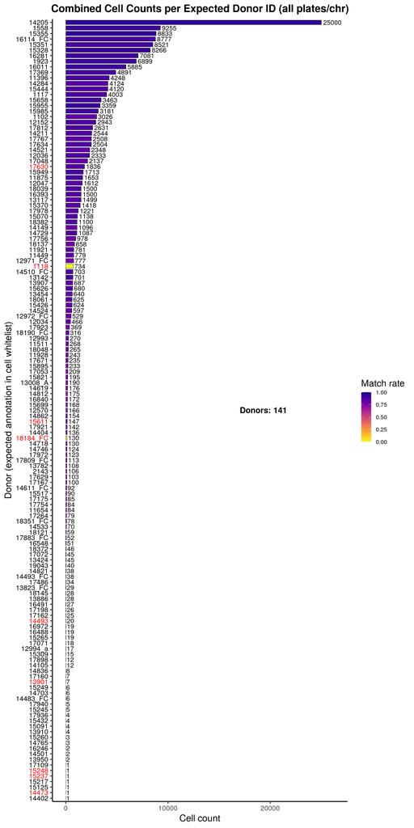

#### Low counts

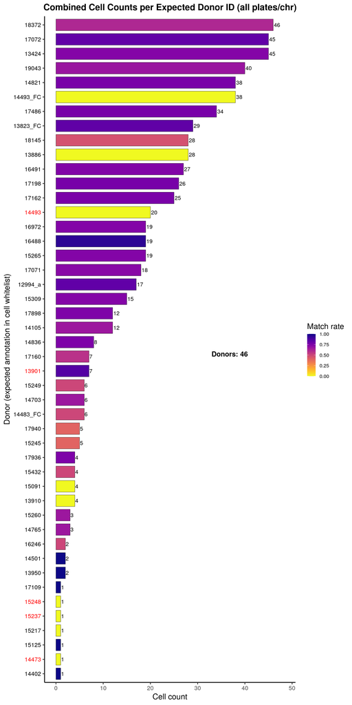

### Benchmarking

#### Table

|  | rule | n | mean_runtime_min | sd_runtime_min | mean_ram_gb | sd_ram_gb |
| --- | --- | --- | --- | --- | --- | --- |
| 1 | cellsnp_lite | 486 | 96.142 | 39.604 | 0.071 | 0.011 |
| 2 | copy_bam | 20 | 89.421 | 33.303 | 0.006 | 0 |
| 3 | extract_chr | 2 | 0.762 | 0.112 | 0.101 | 0.017 |
| 4 | extract_recode | 484 | 2.366 | 1.227 | 0.069 | 0.007 |
| 5 | index_bam | 22 | 6.384 | 1.118 | 0.26 | 0.04 |
| 6 | recode_bam_chr | 2 | 0.598 | 0.004 | 0.026 | 0.022 |
| 7 | sort_bam | 22 | 56.254 | 11.268 | 67.472 | 0.728 |
| 8 | vireo | 485 | 24.831 | 6.925 | 113.597 | 49.366 |

#### Plot

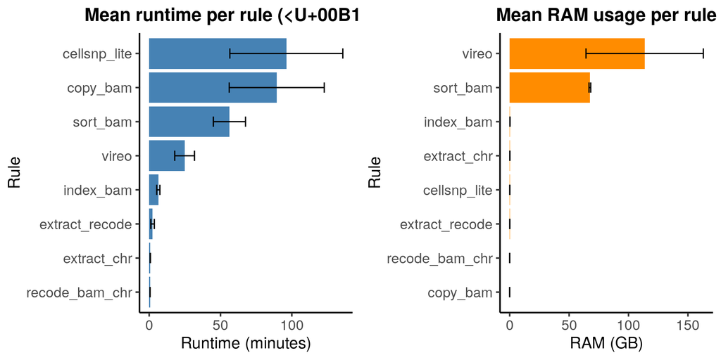